# Report of Housing and Household Income for the Portland Metro Area

In this report, we explore the trend of households and housing units in the Portland metropolitan area between 2012 and 2017 using data from the American Community Survey. The data are downloaded from the Census Beaurea using [the Census API](http://api.census.gov/) and this report is dynamically generated using [R Markdown](https://rmarkdown.rstudio.com).

## Growth of Households and Housing Units by County

As shown in Figure @ref(fig:fig-hh-du), Clackamas County witnessed that its grwoth of households far outpaced that of housing between 2012 and 2017, while the growth of households and housing matched more closely in Multnomah County and Washington County.

Growth of Households and Housing Units by County 2012-17 (2012 value=1). Data Source: US Census Beaurea, American Community Survey 1 year, 2012-17

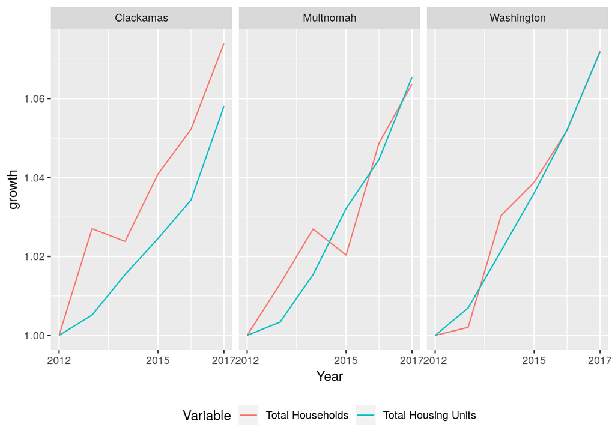

A question of interest is how much of the housing shortage translated into increase in housing value. Table @ref(tab:hhinc-hval) shows median household income and median housing value. According to these two measures, the gap in housing units in Clackamas County has not brought larger increase in median housing value, as the median housing value increased 44% in Clackamas County between 2012 and 2017, lower than the increase in Multnomah County and Washington County (54% and 49%, respectively), while the increase in median household income in the same period are almost similar at 24-28%.

Median Household Income and Median Housing Value by County 2012-17

| County | Year | Median Household Income | Median Housing Value |
| --- | --- | --- | --- |
| Clackamas | 2012 | $64,410 | $281,100 |
| Clackamas | 2013 | $66,758 | $294,800 |
| Clackamas | 2014 | $65,316 | $302,300 |
| Clackamas | 2015 | $69,629 | $336,200 |
| Clackamas | 2016 | $74,891 | $374,900 |
| Clackamas | 2017 | $79,878 | $404,200 |
| Multnomah | 2012 | $51,799 | $255,600 |
| Multnomah | 2013 | $54,024 | $274,700 |
| Multnomah | 2014 | $53,660 | $290,400 |
| Multnomah | 2015 | $59,231 | $321,700 |
| Multnomah | 2016 | $62,629 | $367,700 |
| Multnomah | 2017 | $63,974 | $393,900 |
| Washington | 2012 | $63,530 | $265,100 |
| Washington | 2013 | $63,238 | $277,000 |
| Washington | 2014 | $66,136 | $291,500 |
| Washington | 2015 | $70,447 | $322,400 |
| Washington | 2016 | $75,634 | $361,400 |
| Washington | 2017 | $80,946 | $394,000 |